# Gestalt Principles in Data Visualization (Claude 3.5)

## A Guide to Perceptual Organization in Visual Analytics

### Introduction

#### The Gestalt principles, developed by German psychologists in the 1920s, describe how humans naturally perceive and organize visual information. These principles are fundamental to effective data visualization design, helping us create more intuitive and impactful visualizations.

### *1. Proximity*:

#### Objects that are closer together are perceived as related. **Example Visualization:** library(ggplot2) library(dplyr) # Create sample data proximity_data <- data.frame( x = rep(1:4, each = 2), y = rep(1:2, times = 4), group = rep(c("A", "B"), times = 4) ) ggplot(proximity_data, aes(x, y)) + geom_point(size = 4) + scale_x_continuous(breaks = 1:4) + theme_minimal() + labs(title = "Proximity Principle", subtitle = "Points closer together are perceived as grouped") **Application Guideline**: - Place related data elements close together - Use consistent spacing to indicate relationships - Create logical groupings through spatial arrangement

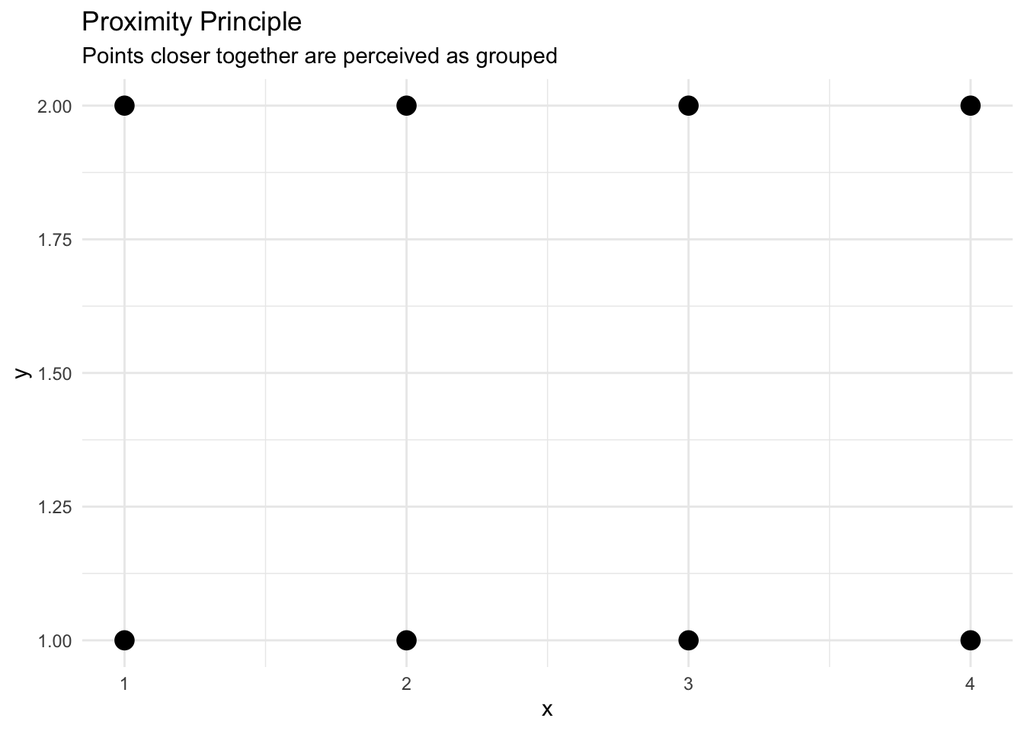

### *2. Similarity*

#### Objects sharing visual properties (color, shape, size) are perceived as related. **Example Visualization:** library(ggplot2) # Create sample data similarity_data <- data.frame( category = rep(c("A", "B", "C"), each = 4), value = c(10, 15, 12, 18, 20, 22, 19, 25, 30, 28, 32, 35), group = rep(c("Group 1", "Group 2"), times = 6) ) ggplot(similarity_data, aes(x = category, y = value, fill = group)) + geom_bar(stat = "identity", position = "dodge") + scale_fill_brewer(palette = "Set2") + theme_minimal() + labs(title = "Similarity Principle", subtitle = "Similar colors indicate related groups") **Application Guideline**: - Use consistent colors for related metrics - Apply similar shapes to related data points - Maintain consistent sizing for related elements

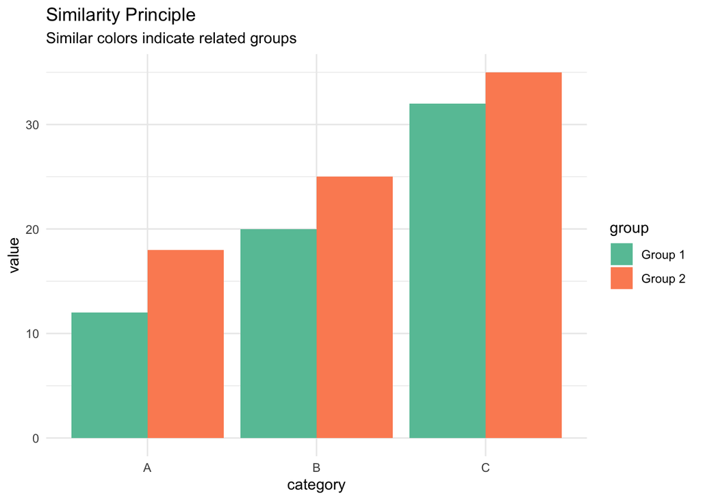

### 3. Continuity

#### Elements arranged in a continuous line or curve are perceived as related. **Example Visualization:** library(ggplot2) # Create sample data set.seed(123) continuity_data <- data.frame( x = 1:20, y1 = cumsum(rnorm(20, 0, 0.5)), y2 = cumsum(rnorm(20, 0, 0.5)) ) ggplot(continuity_data, aes(x = x)) + geom_line(aes(y = y1, color = "Series 1")) + geom_line(aes(y = y2, color = "Series 2")) + theme_minimal() + labs(title = "Continuity Principle", subtitle = "Lines guide the eye along continuous paths") **Application Guideline**: - Use smooth transitions in line charts - Align elements along natural reading paths - Create clear visual flows

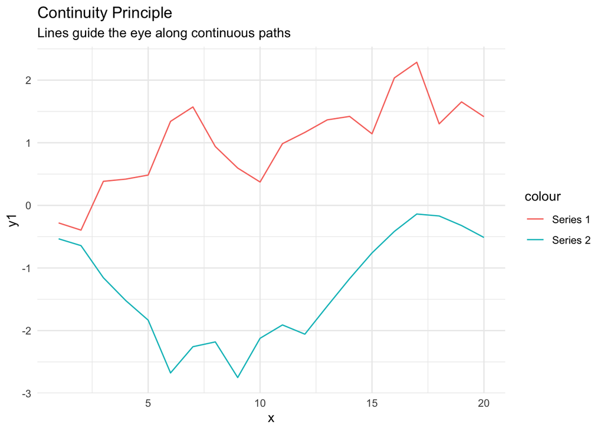

### 4. Closure

#### The mind tends to complete incomplete forms. **Example Visualization:** library(ggplot2) # Create sample data for a partial border plot closure_data <- data.frame( x = c(1, 2, 3, 4, 5), y = c(2, 4, 3, 5, 4) ) ggplot(closure_data, aes(x, y)) + geom_point() + geom_segment(aes(x = x, xend = lead(x), y = y, yend = lead(y)), lty=3, data = head(closure_data, -1)) + theme_minimal() + theme(panel.border = element_blank()) + labs(title = "Closure Principle", subtitle = "Mind completes the implied shape") **Application Guideline**: - Use partial borders when full borders aren’t necessary - Allow white space to define boundaries - Leverage implied shapes and patterns

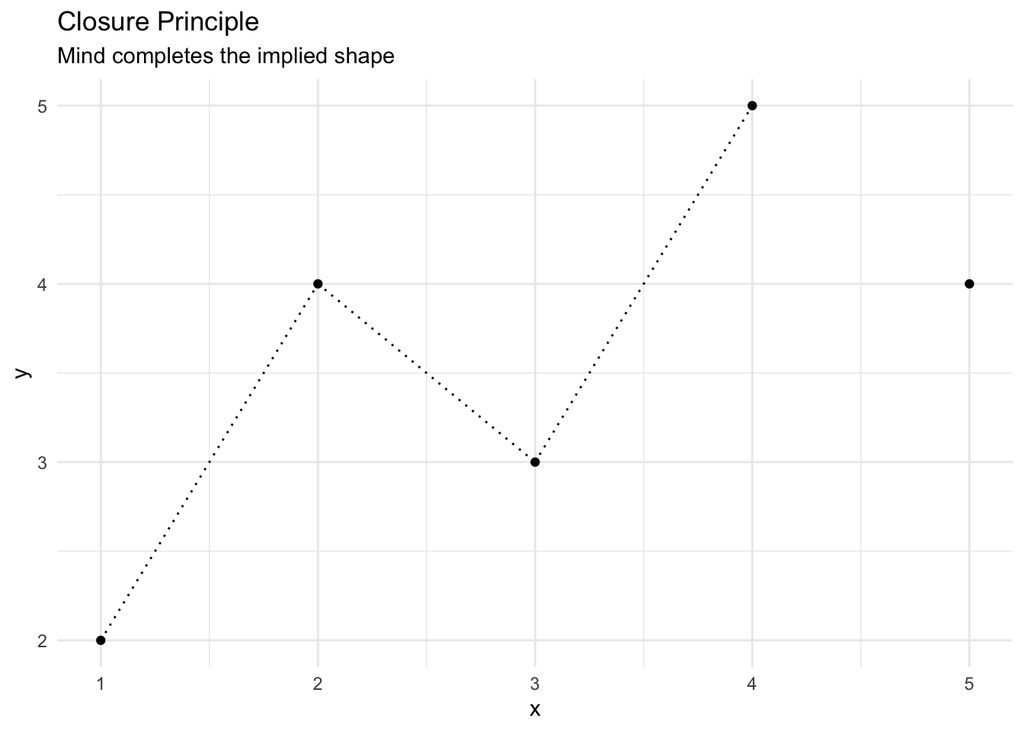

### 5. Figure-Ground

#### Objects are perceived as either figures (focus) or ground (background). **Example Visualization:** library(ggplot2) # Create sample data figure_ground_data <- data.frame( x = 1:10, y = c(5, 7, 4, 8, 6, 9, 7, 8, 6, 7), highlight = c(rep(FALSE, 7), TRUE, TRUE, FALSE) ) ggplot(figure_ground_data, aes(x, y)) + geom_line(color = "gray80", size = 1) + geom_line(data = subset(figure_ground_data, highlight), color = "red", size = 2) + theme_minimal() + labs(title = "Figure-Ground Principle", subtitle = "Important elements stand out from background") **Application Guideline**: - Create clear visual hierarchy - Use contrast to emphasize important data - Keep background elements subtle

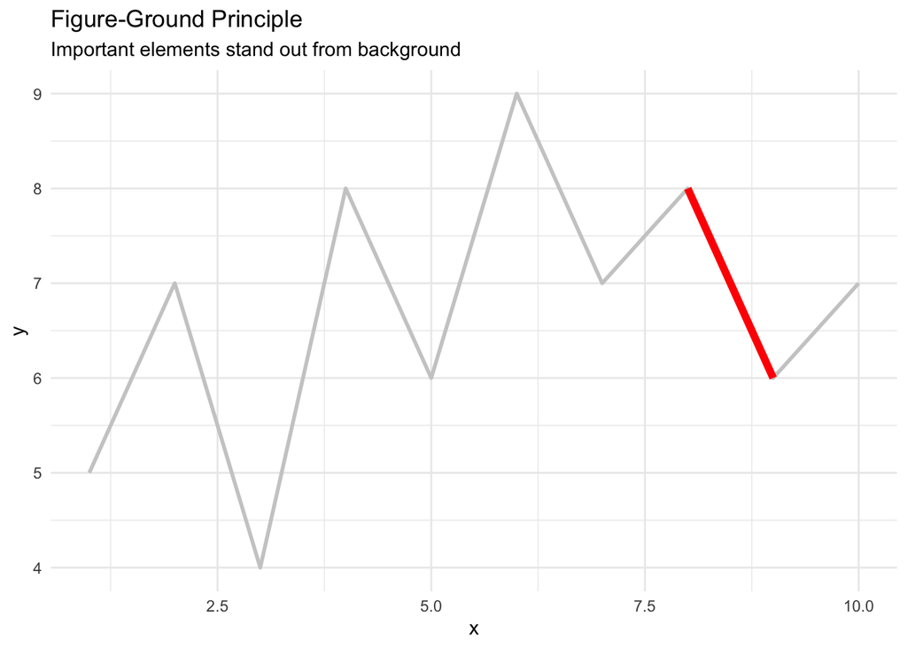

### Organizational Guidelines Based on Gestalt Principles

### 1. Dashboard Layout

#### Group related metrics spatially (Proximity) Use consistent styling for similar metrics (Similarity) Create clear visual hierarchies (Figure-Ground) **Example:** library(ggplot2) library(patchwork) # Create sample dashboard layout plot1 <- ggplot(mtcars, aes(wt, mpg)) + geom_point() + theme_minimal() + labs(title = "Weight vs MPG") plot2 <- ggplot(mtcars, aes(hp, mpg)) + geom_point() + theme_minimal() + labs(title = "Horsepower vs MPG") plot1 + plot2 + plot_layout(ncol = 2) + plot_annotation(title = "Vehicle Performance Metrics")

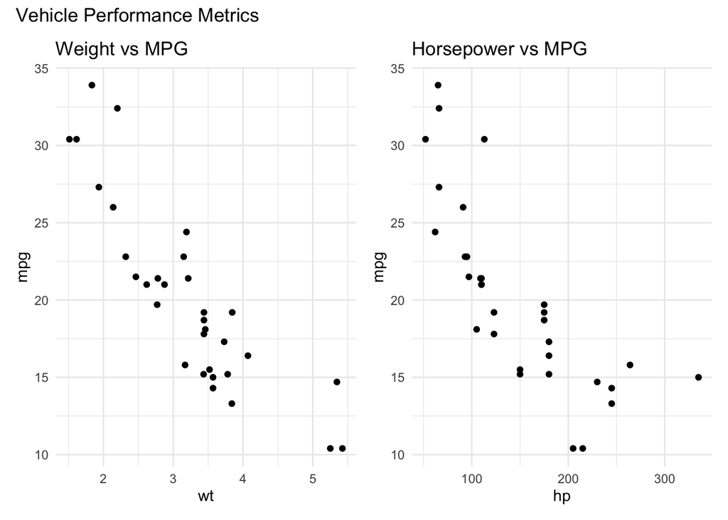

### 2. Color Usage

#### Use similar colors for related data (Similarity) Create clear contrast between data and background (Figure-Ground) Maintain consistent color meaning across visualizations **Example:** library(ggplot2) # Create consistent color palette org_colors <- scale_color_manual( values = c("primary" = "#1f77b4", "secondary" = "#ff7f0e", "warning" = "#d62728") ) # Apply to visualization ggplot(economics, aes(x = date)) + geom_line(aes(y = unemploy, color = "primary")) + org_colors + theme_minimal() + labs(title = "Unemployment Trend", color = "Metric Type")

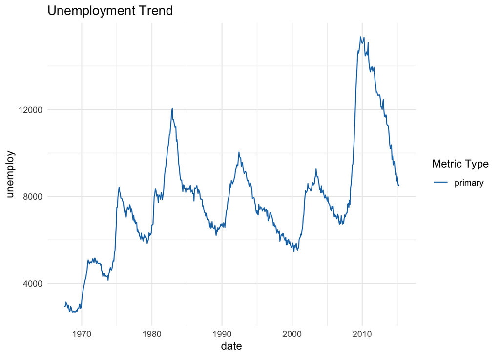

### 3. Information Hierarchy

#### Emphasize important information through size and position Use white space effectively Create clear visual paths through the data **Example:** library(ggplot2) ggplot(economics, aes(x = date, y = unemploy)) + geom_area(fill = "lightgray", alpha = 0.5) + geom_line(color = "darkblue") + geom_point(data = economics[economics$unemploy == max(economics$unemploy),], color = "red", size = 3) + theme_minimal() + labs(title = "Unemployment Trend with Emphasis", subtitle = "Peak point highlighted")

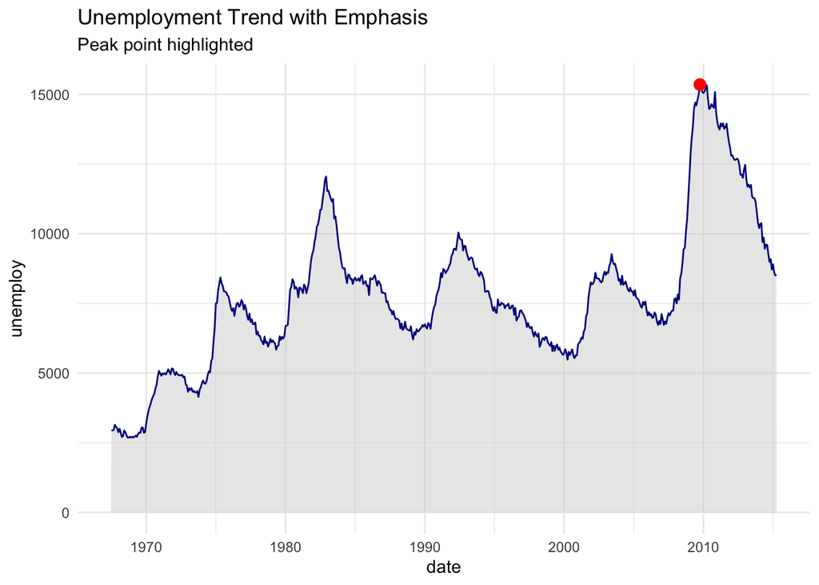

### Best Practices for Implementation

#### **Consistency** Maintain consistent styling across all visualizations Use standardized layouts for similar information Apply uniform color coding **Simplicity** Remove unnecessary visual elements Use white space effectively Focus on essential information **Hierarchy** Establish clear visual importance Guide viewer attention Create logical information flow

### Conclusion

#### Gestalt principles provide a powerful framework for creating effective data visualizations. By understanding and applying these principles, we can create more intuitive, engaging, and impactful visual analytics that better serve our organization’s needs.

### Resources and References

1. Stephen Few - “Information Dashboard Design”
2. Edward Tufte - “The Visual Display of Quantitative Information”
3. Colin Ware - “Information Visualization: Perception for Design”